# Practical Machine Learning - Coursera

Mustofa Husni Sanoval

2025-03-05

# Introduction

# Load Data

```r
training <- read.csv("./pml-training.csv", na.strings = c("NA", "#DIV/0!", ""))
testing <- read.csv("./pml-testing.csv", na.strings = c("NA", "#DIV/0!", ""))

# Data dimensions
dim(training)
```

```
## [1] 19622   160
```

```r
dim(testing)
```

```
## [1]  20 160
```

# Data Preprocessing

To ensure the dataset is clean and suitable for training, we perform the following preprocessing steps: 1. **Split the training set** into 70% training and 30% testing. 2. **Remove near-zero variance predictors**, as they contribute little to the model. 3. **Remove columns with more than 50% missing values**. 4. **Ensure consistency** between the training and test datasets.

```r
set.seed(12345)

# Split training data
inTrain <- createDataPartition(y = training$classe, p = 0.7, list = FALSE)
training.set <- training[inTrain,]
testing.set <- training[-inTrain,]

# Remove near-zero variance predictors
nzv <- nearZeroVar(training.set, saveMetrics = TRUE)

# Remove columns with more than 50% missing values
ind.NA <- colSums(is.na(training.set)) < (0.5 * nrow(training.set))

# Select only relevant columns
valid_columns <- ind.NA & !nzv$nzv
training.set <- training.set[, valid_columns]
testing.set <- testing.set[, valid_columns]
testing <- testing[, valid_columns]

# Remove ID columns
training.set <- training.set[, -1]
testing.set <- testing.set[, -1]
testing <- testing[, -1]
```

# Data Consistency Check

```r
# Ensure data types match across datasets
training.set <- training.set %>% mutate_if(is.character, as.factor)
testing.set <- testing.set %>% mutate_if(is.character, as.factor)
testing <- testing %>% mutate_if(is.character, as.factor)

# Ensure column names are identical
print(setdiff(colnames(training.set), colnames(testing))) # Columns in training but not in testing
```

```
## [1] "classe"
```

```r
print(setdiff(colnames(testing), colnames(training.set))) # Columns in testing but not in training
```

```
## [1] "problem_id"
```

```r
# Standardize factor levels
for (col in colnames(training.set)) {
  if (is.factor(training.set[[col]])) {
    if (col %in% colnames(testing)) {
      new_levels <- unique(c(levels(training.set[[col]]), levels(as.factor(testing[[col]]))))
      training.set[[col]] <- factor(training.set[[col]], levels = new_levels)
      testing[[col]] <- factor(testing[[col]], levels = new_levels)
    }
  }
}

# Remove columns with all NA values in testing
testing <- testing[, colSums(is.na(testing)) < nrow(testing)]

# Ensure consistency
print(all(colnames(training.set) == colnames(testing)))
```

```
## [1] FALSE
```

# Train Decision Tree

A Decision Tree is a simple yet interpretable model. We use it as a baseline before moving to more complex models.

[figure not shown]

```r
set.seed(12345)
tree.fit <- train(y = training.set$classe,
                  x = training.set[, -ncol(training.set)],
                  method = "rpart")

# Plot decision tree
rattle::fancyRpartPlot(tree.fit$finalModel)
```

# Decision Tree Predictions

The model’s performance is evaluated using a confusion matrix.

```r
pred.tree <- predict(tree.fit, testing.set[, -ncol(testing.set)])
pred.tree <- factor(pred.tree, levels = levels(training.set$classe))
testing.set$classe <- factor(testing.set$classe, levels = levels(training.set$classe))

# Confusion Matrix for Decision Tree
conf.tree <- confusionMatrix(pred.tree, testing.set$classe)
print(conf.tree)
```

```
## Confusion Matrix and Statistics
##
##           Reference
## Prediction    A    B    C    D    E
##          A 1042  108    0    0    0
##          B  632 1023  763  167    0
##          C    0    0    0    0    0
##          D    0    0    0    0    0
##          E    0    8  263  797 1082
##
## Overall Statistics
##
##                Accuracy : 0.5347
##                  95% CI : (0.5219, 0.5476)
##     No Information Rate : 0.2845
##     P-Value [Acc > NIR] : < 2.2e-16
##
##                   Kappa : 0.4127
##
##  Mcnemar's Test P-Value : NA
##
## Statistics by Class:
##
##                      Class: A Class: B Class: C Class: D Class: E
## Sensitivity            0.6225   0.8982   0.0000   0.0000   1.0000
## Specificity            0.9744   0.6709   1.0000   1.0000   0.7776
## Pos Pred Value         0.9061   0.3957      NaN      NaN   0.5033
## Neg Pred Value         0.8665   0.9648   0.8257   0.8362   1.0000
## Prevalence             0.2845   0.1935   0.1743   0.1638   0.1839
## Detection Rate         0.1771   0.1738   0.0000   0.0000   0.1839
## Detection Prevalence   0.1954   0.4393   0.0000   0.0000   0.3653
## Balanced Accuracy      0.7984   0.7845   0.5000   0.5000   0.8888
```

```r
# Accuracy & Kappa
print(paste("Accuracy:", conf.tree$overall["Accuracy"]))
```

```
## [1] "Accuracy: 0.534749362786746"
```

```r
print(paste("Kappa:", conf.tree$overall["Kappa"]))
```

```
## [1] "Kappa: 0.412733516999174"
```

# Train Random Forest Model

Random Forest is chosen for its high accuracy and ability to handle complex relationships.

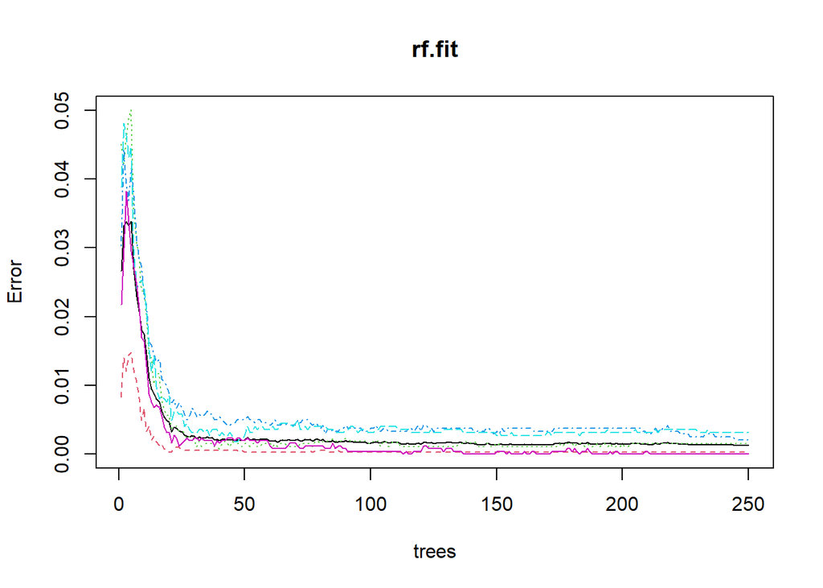

```r
set.seed(12345)
rf.fit <- randomForest(classe ~ ., data = training.set, ntree = 250)

# Plot Random Forest Model
plot(rf.fit)
```

# Random Forest Predictions

```r
pred.rf <- predict(rf.fit, testing.set[, -ncol(testing.set)])
pred.rf <- factor(pred.rf, levels = levels(training.set$classe))
testing.set$classe <- factor(testing.set$classe, levels = levels(training.set$classe))

# Confusion Matrix for Random Forest
conf.rf <- confusionMatrix(pred.rf, testing.set$classe)
print(conf.rf)
```

```
## Confusion Matrix and Statistics
##
##           Reference
## Prediction    A    B    C    D    E
##          A 1674    0    0    0    0
##          B    0 1139    1    0    0
##          C    0    0 1019    5    0
##          D    0    0    6  959    0
##          E    0    0    0    0 1082
##
## Overall Statistics
##
##                Accuracy : 0.998
##                  95% CI : (0.9964, 0.9989)
##     No Information Rate : 0.2845
##     P-Value [Acc > NIR] : < 2.2e-16
##
##                   Kappa : 0.9974
##
##  Mcnemar's Test P-Value : NA
##
## Statistics by Class:
##
##                      Class: A Class: B Class: C Class: D Class: E
## Sensitivity            1.0000   1.0000   0.9932   0.9948   1.0000
## Specificity            1.0000   0.9998   0.9990   0.9988   1.0000
## Pos Pred Value         1.0000   0.9991   0.9951   0.9938   1.0000
## Neg Pred Value         1.0000   1.0000   0.9986   0.9990   1.0000
## Prevalence             0.2845   0.1935   0.1743   0.1638   0.1839
## Detection Rate         0.2845   0.1935   0.1732   0.1630   0.1839
## Detection Prevalence   0.2845   0.1937   0.1740   0.1640   0.1839
## Balanced Accuracy      1.0000   0.9999   0.9961   0.9968   1.0000
```

```r
# Accuracy & Kappa
print(paste("Accuracy:", conf.rf$overall["Accuracy"]))
```

```
## [1] "Accuracy: 0.997960917587086"
```

```r
print(paste("Kappa:", conf.rf$overall["Kappa"]))
```

```
## [1] "Kappa: 0.99742082805882"
```

# Predict for Test Dataset

Finally, we apply the trained model to the test dataset and save the predictions.

```r
pred.validation <- predict(rf.fit, testing)

# Save predictions
testing$pred.classe <- pred.validation
write.table(
  pred.validation,
  file = "predictions.txt",
  quote = FALSE,
  row.names = FALSE,
  col.names = FALSE
)
```

# Conclusion

This report describes the steps taken to clean the dataset, train machine learning models, and evaluate their performance. We used a Decision Tree as a baseline and then applied a Random Forest model, which demonstrated higher accuracy. The final predictions were saved for submission. Future improvements could involve hyperparameter tuning or using other ensemble methods.